# xwMOOC 모형

Cloudera: 고객이탈 - LIME

xwMOOC

Tidyverse Korea

2018-11-04

# 1 고객이탈 설명

예측성능이 좋은 예측모형을 설명하기 위해서 예측모형 자체를 설명하는 것과 함께 이를 활용하는 사업에 대한 설명을 넘어 고객에게 설명하는 부분까지 확장해 나가고 있다.

- 예측모형 제작자
- 예측모형 활용
- 예측모형 대상 고객

# 2 고객이탈 데이터 정제

`.csv` 데이터를 `read_csv()`를 통해 불러와서 변수명과 변수 자료형을 향수 분석에 맞게 조정한다.

```r
library(tidyverse)
library(janitor)
library(skimr)

churn_dat <- read_csv("data/WA_Fn-UseC_-Telco-Customer-Churn.csv")

churn_dat <- churn_dat %>%
  clean_names()

churn_list <- skim_to_list(churn_dat)

churn_df <- churn_dat %>%
  mutate(churn = factor(churn, levels = c("No", "Yes"))) %>%
  mutate(senior_citizen = factor(senior_citizen)) %>%
  mutate(multiple_lines    = ifelse(str_detect(multiple_lines, "No"), "No", "Yes"),
         internet_service  = ifelse(str_detect(internet_service, "No"), "No", "Yes"),
         online_security   = ifelse(str_detect(online_security, "No"), "No", "Yes"),
         online_backup     = ifelse(str_detect(online_backup, "No"), "No", "Yes"),
         device_protection = ifelse(str_detect(device_protection, "No"), "No", "Yes"),
         tech_support      = ifelse(str_detect(tech_support, "No"), "No", "Yes"),
         streaming_tv      = ifelse(str_detect(streaming_tv, "No"), "No", "Yes"),
         streaming_movies  = ifelse(str_detect(streaming_movies, "No"), "No", "Yes")) %>%
  select(-customer_id) %>%
  mutate_if(is.character, as.factor) %>%
  filter(complete.cases(.))
```

# 3 예측모형 생성

## 3.1 훈련/시험 데이터 생성

`caret` 팩키지를 활용하여 훈련데이터와 검증데이터로 분리한다.

```r
library(caret)

index_train <- createDataPartition(churn_df$churn, p = 0.5, list = FALSE)

train_df <- churn_df[index_train, ]
test_df  <- churn_df[-index_train, ]

## 2.2. 모형 개발/검증 데이터셋 준비 ------

cv_folds <- createMultiFolds(train_df$churn, k = 5, times = 3)

cv_ctrl <- trainControl(method = "repeatedcv", number = 5,
                         repeats = 3,
                         index = cv_folds)


## 2.2. 모형 개발/검증 데이터셋 준비 ------

library(doSNOW)
# 실행시간
start.time <- Sys.time()

cl <- makeCluster(8, type = "SOCK")
registerDoSNOW(cl)


churn_rf  <- train(churn ~ ., data = train_df,
                   method = "rf",
                   trControl = cv_ctrl,
                   tuneLength = 15,
                   importance = TRUE)

churn_glm  <- train(churn ~ ., data = train_df,
                    method = "glm",
                    family="binomial")


stopCluster(cl)

total.time <- Sys.time() - start.time
total.time
```

```
Time difference of 3.898562 mins
```

# 4 모형설명

## 4.1 모형 아키텍처

예측모형을 개발할 경우 가능하면 다른 조건이 동일하다면 단순한 예측모형이 좋다. 블랙박스 예측모형의 성능이 일반화 선형모형과 별차이가 없다면 당연히 일반화 선형모형을 사용하는 것이 최선일 수 있다. 따라서, 가장 먼저 예측모형 아키텍처를 모형성능에 따라 선정하는 과정을 거친다.

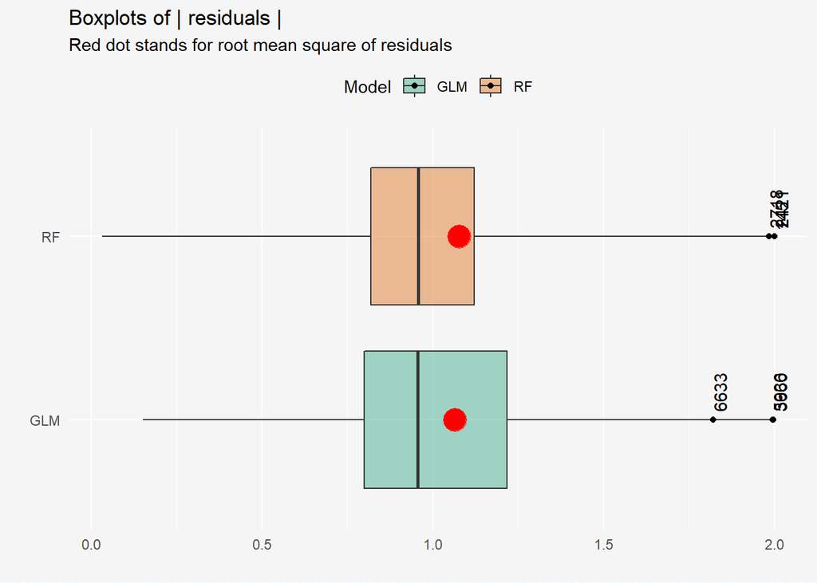

```r
library(DALEX)
# 3. DALEX 설정 -----
## 3.1. explainer 사전 설정
prob_fun <- function(object, newdata) {
    predict(object, newdata=newdata, type="prob")[,2]
}

test_v <- as.numeric(test_df$churn)

## 3.2. explainer 실행
explainer_glm <- DALEX::explain(churn_glm, label = "GLM",
                                data = test_df[, !(colnames(test_df) %in% c("churn"))], y = test_v,
                                predict_function = prob_fun)

explainer_rf <- DALEX::explain(churn_rf, label = "RF",
                               data = test_df[, !(colnames(test_df) %in% c("churn"))], y = test_v,
                               predict_function = prob_fun)

# 4. 예측 모형 이해와 설명 -----
## 4.1. 모형 성능
mp_glm <- model_performance(explainer_glm)
mp_rf  <- model_performance(explainer_rf)

plot(mp_rf, mp_glm, geom = "boxplot", show_outliers = 3) +
    theme(legend.position = "top")
```

## 4.2 중요변수 추출

예측모형마다 예측성능에 사용된 중요변수가 차이가 있다. 각 모형 아키텍처마다 중요변수를 추출하여 각 예측모형에 공통적으로 선택되고 중요 변수 순위를 식별한다.

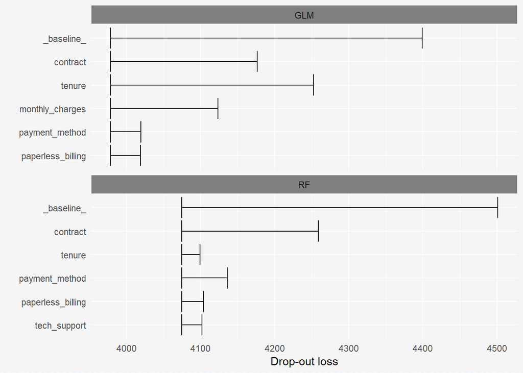

```r
## 4.2. 중요 변수
vi_glm <- variable_importance(explainer_glm, n_sample = -1, type = "raw")
vi_rf  <- variable_importance(explainer_rf,  n_sample = -1, type = "raw")

plot(vi_glm, vi_rf, max_vars = 6)
```

## 4.3 반응변수 연관

추려진 중요변수를 뽑아서 중요변수와 반응변수 사이 연관성을 살펴본다.

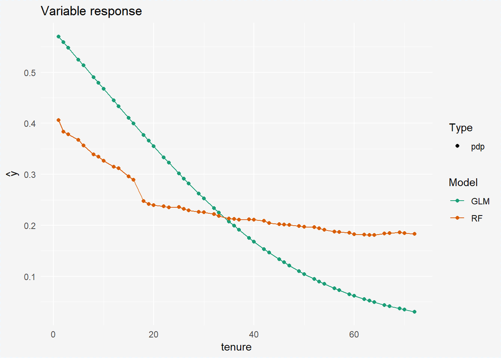

```r
## 4.3. 변수 반응도
pdp_glm <- variable_response(explainer_glm, variable = "tenure", type = "pdp")
pdp_rf  <- variable_response(explainer_rf,  variable = "tenure", type = "pdp")

plot(pdp_glm, pdp_rf)
```

# 5 예측설명 [^1]

예측에 기여한 변수와 가중치를 각 관측점별로 식별한다. `plot_explanations()` 함수를 통해서 관측점별로 긍정적인 부정적인 영향을 주는 변수가 어떤 것인지도 시각화를 통해 판별한다.

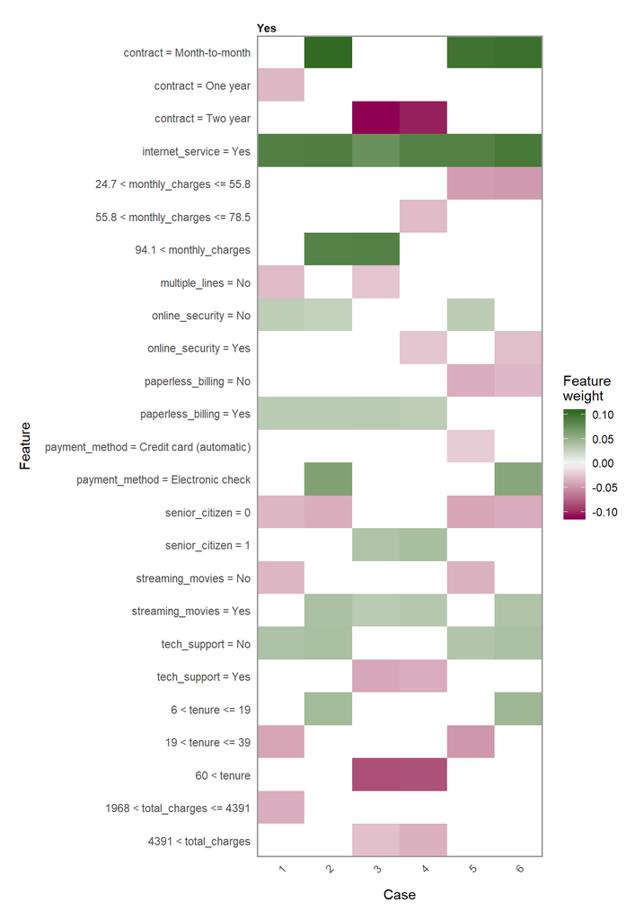

```r
library(lime)
set.seed(777)
predict_obs <- test_df %>%
  sample_n(6)

explainer_caret <- lime(train_df, churn_rf, n_bins = 5)

explanation_caret <- explain(
  x = predict_obs,
  explainer = explainer_caret,
  n_permutations = 5000,
  dist_fun = "gower",
  kernel_width = .75,
  n_features = 10,
  feature_select = "highest_weights",
  labels = "Yes")

plot_explanations(explanation_caret)
```

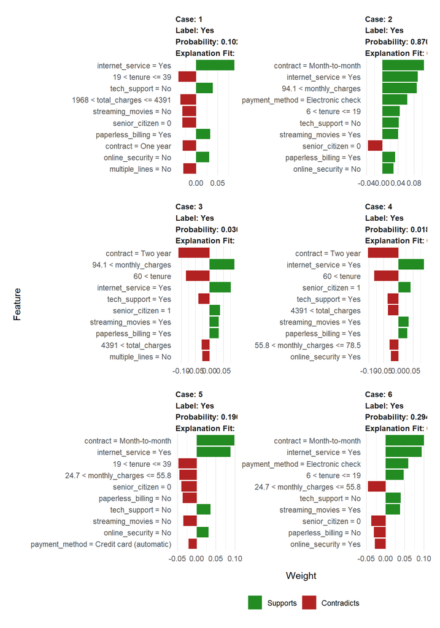

```r
plot_features(explanation_caret)
```

# 6 사업 예측설명

최근에 `mlr` 뿐만 아니라 `caret`에 대한 지원도 시작했다. 이를 통해서 Lift, Gain 등 예측모형에 대한 사업적인 설명도 한층 탄력을 받게 되었다.

```r
library(modelplotr) # install_github("modelplot/modelplotr")

prepare_scores_and_deciles(datasets=list("train_df","test_df"),
  dataset_labels = list("train data","test data"),
  models = list("churn_glm","churn_rf"),
  model_labels = list("GLM", "Random Forest"),
  target_column="churn")
```

```
... scoring caret model "churn_glm" on dataset "train_df".
... scoring caret model "churn_rf" on dataset "train_df".
... scoring caret model "churn_glm" on dataset "test_df".
... scoring caret model "churn_rf" on dataset "test_df".
```

```
[1] "Data preparation step 1 succeeded! Dataframe 'scores_and_deciles' created."
```

```r
plotting_scope(select_model_label = 'Random Forest', select_dataset_label = 'test data')
```

```
[1] "deciles_aggregate not available; input_modelevalplots() is run..."
Data preparation step 3 succeeded! Dataframe 'plot_input' created.

No comparison specified, default values are used.

Single evaluation line will be plotted: Target value "Yes" plotted for dataset "test data" and model "Random Forest.
"
-> To compare models, specify: scope = "compare_models"
-> To compare datasets, specify: scope = "compare_datasets"
-> To compare target classes, specify: scope = "compare_targetclasses"
-> To plot one line, do not specify scope or specify scope = "no_comparison".
```

```
Plot annotation:
- When we select 20% with the highest probability according to Random Forest, this selection holds 49% of all Yes cases in test data.
```

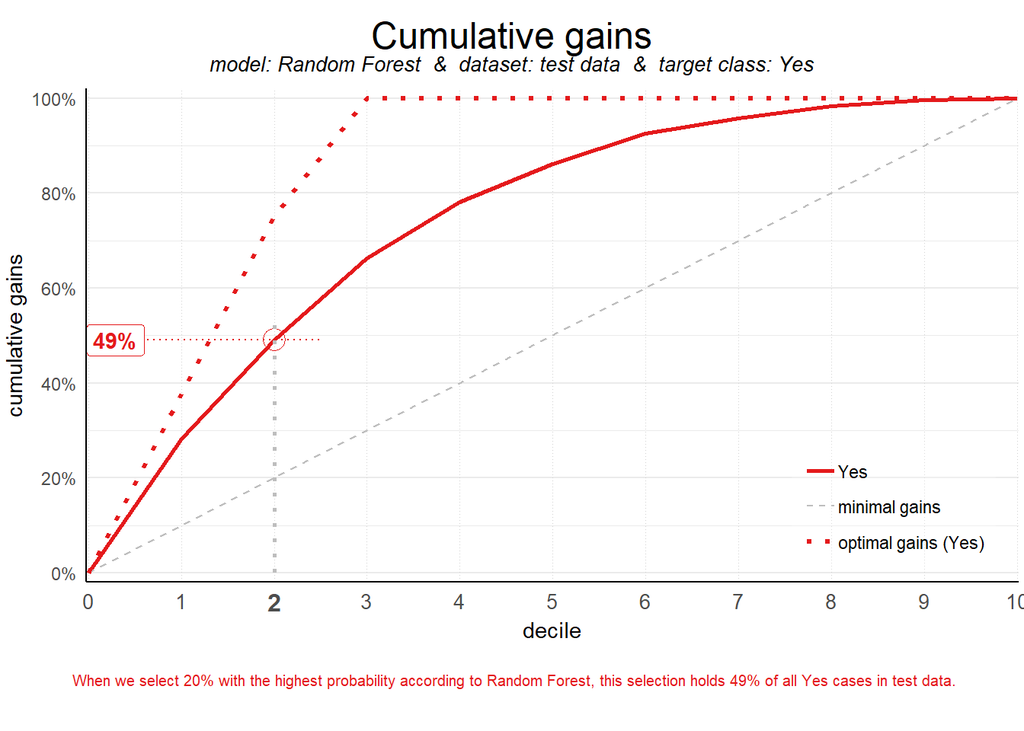

```r
plot_cumgains(highlight_decile = 2)
```

```
Plot annotation:
- When we select 20% with the highest probability according to model Random Forest in test data, this selection for Yes cases is 2.5 times better than selecting without a model.
```

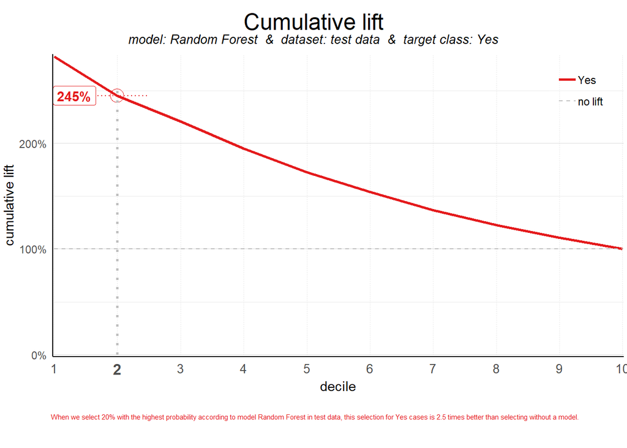

```r
plot_cumlift(highlight_decile = 2)
```

```
Plot annotation:
- When we select decile 2 according to model Random Forest in dataset test data the % of Yes cases in the selection is 55%.
```

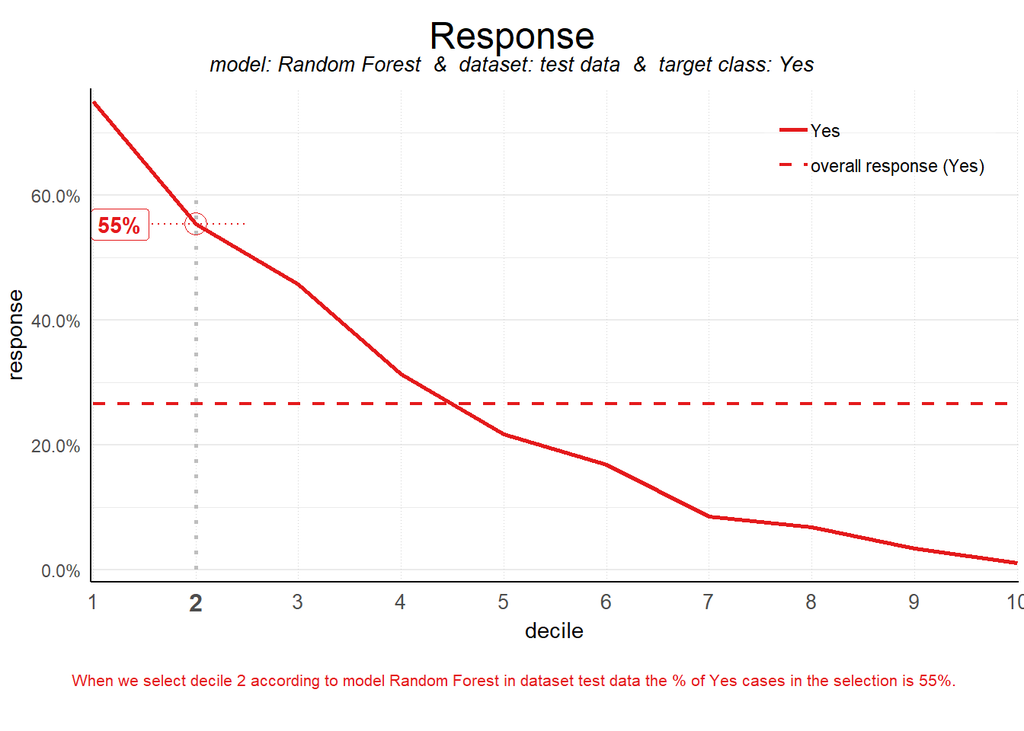

```r
plot_response(highlight_decile = 2)
```

[^1]: [Visualizing ML Models with LIME](https://uc-r.github.io/lime)